# ETC5512: Solutions for Lab 6

Patricia Menéndez

# Reading libraries

```r
library(tidyverse)
library(leaflet)
library(ggmap)
library(readr)
library(mapview)
library(viridis)
library(rgdal)
library(lubridate)
```

# Tutorial Objectives

- Explore LTMP data measurements for hard coral cover and algae cover.
- Visualize variability in mean estimates.
- Run a simple regression model.
- Practice your data wrangling skills.

# Exercise 2: Create a report and read the data

- Create an Rstudio project.
- Inside your Rstudio project folder create a reproducible Rmd file called *tutorial6.Rmd*. The file should render into an html file.
- Add the *Data* folder place the LTMP data inside that folder.
- Read the LTMP data.

```r
# LTMP data
ltmp <- read_csv(file = "Data/ltmp_hc_sc_a_by_site/ltmp_hc_sc_a_by_site.csv", col_types = cols())
```

- Add an R code chunk to include the relevant R libraries at the top of the *tutorial6.Rmd* file.
- Prepare the data so that you can create the following figures and discuss the differences between those graphs:

**Hint:**

```r
ltmp %>% dplyr::filter(GROUP_CODE == "Hard Coral",
                           SECTOR == XX
                           ) %>%
                    mutate(REEF_NAME = as.factor(REEF_NAME),
                    Year = year(XX)) %>%
                   group_by(SECTOR, SHELF, Year) %>%
  summarise(covermean = mean(XX, na.rm = TRUE),
                        coversd = sd(XX, na.rm = TRUE),
                        samplesize = n()) %>%
  mutate(upper = covermean + coversd/sqrt(samplesize),
         lower = covermean - coversd/sqrt(samplesize))
```

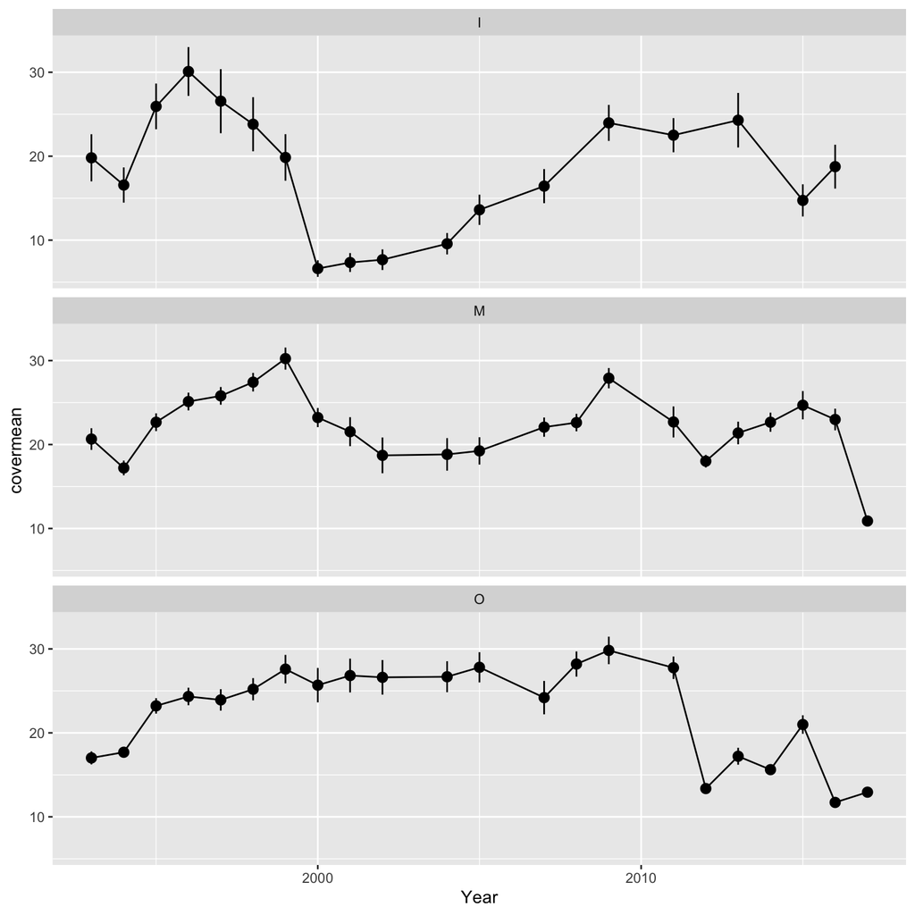

```r
plot1dat = ltmp %>% dplyr::filter(GROUP_CODE == "Hard Coral",
                           SECTOR == "CA",
                           SITE_NO %in% c("1", "2", "3")
                           ) %>%
  mutate(REEF_NAME = as.factor(REEF_NAME),
         Year = year(SAMPLE_DATE)) %>%
  group_by(SECTOR, SHELF, Year) %>%
  summarize_at(vars(COVER), list(covermean = mean, coversd = sd)) %>%
  mutate(samplesize = n()) %>%
  mutate(upper = covermean + coversd/sqrt(samplesize),
         lower = covermean - coversd/sqrt(samplesize))



ggplot(plot1dat, aes( x = Year, y = covermean)) +
  geom_line() +
  geom_pointrange(aes(ymin=lower, ymax=upper)) +
  facet_wrap(~SHELF, ncol = 1)
```

**Hint:**

```r
 ltmp %>% dplyr::filter(GROUP_CODE == XX,
                           SECTOR == "CA") %>%
  mutate(REEF_NAME = as.factor(REEF_NAME),
         Year = year(SAMPLE_DATE)) %>%
  group_by(XX, XX, XX) %>%
  summarize_at(vars(COVER), list(covermean = mean, coversd = sd)) %>%
  mutate(upper = covermean + XX,
         lower = covermean - XX)
```

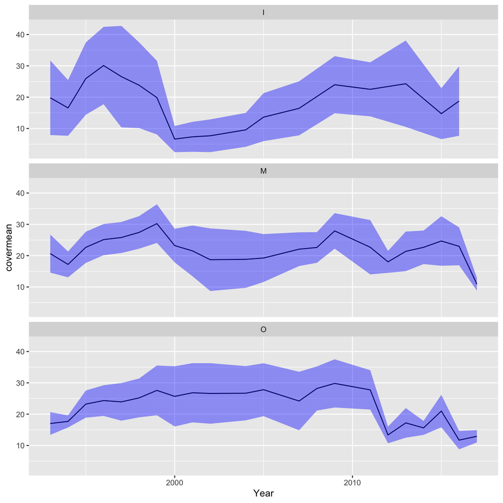

```r
plot2dat = ltmp %>% dplyr::filter(GROUP_CODE == "Hard Coral",
                           SECTOR == "CA",
                           SITE_NO %in% c("1", "2", "3")
                           ) %>%
  mutate(REEF_NAME = as.factor(REEF_NAME),
         Year = year(SAMPLE_DATE)) %>%
  group_by(SECTOR, SHELF, Year) %>%
  summarize_at(vars(COVER), list(covermean = mean, coversd = sd)) %>%
  mutate(upper = covermean + coversd,
         lower = covermean - coversd)


ggplot(plot2dat, aes( x = Year, y = covermean)) +
  geom_line() +
  geom_ribbon(aes(ymin = lower, ymax = upper), fill = "blue", alpha = 0.4) +
  facet_wrap(~SHELF, ncol = 1)
```